# TUGAS MPDW

irsyadparama

2024-09-23

# **Import Data**

```r
library(readxl)
data<- read_excel("C:/Users/Irsyad Parama/Downloads/DATA MPDW.xlsx" , sheet ='201-300')

#memasukan data hanya baris 363 hingga 483 aja
datakeseluruhan<-data[1:101,]
head(datakeseluruhan)
```

```
## # A tibble: 6 × 2
##   Tanggal     Tavg
##   <chr>      <dbl>
## 1 20-07-2023  27.9
## 2 21-07-2023  28.8
## 3 22-07-2023  29.1
## 4 23-07-2023  29
## 5 24-07-2023  28.8
## 6 25-07-2023  28
```

```r
str(datakeseluruhan)
```

```
## tibble [101 × 2] (S3: tbl_df/tbl/data.frame)
##  $ Tanggal: chr [1:101] "20-07-2023" "21-07-2023" "22-07-2023" "23-07-2023" ...
##  $ Tavg   : num [1:101] 27.9 28.8 29.1 29 28.8 28 28 29 28.9 28.6 ...
```

## **Eksplorasi Data**

```r
datakeseluruhan.ts<-ts(datakeseluruhan$`Tavg`)
summary(datakeseluruhan.ts)
```

```
##    Min. 1st Qu.  Median    Mean 3rd Qu.    Max.    NA's
##   27.90   28.70   29.05   29.18   29.60   31.80       1
```

### **Plot Time Series**

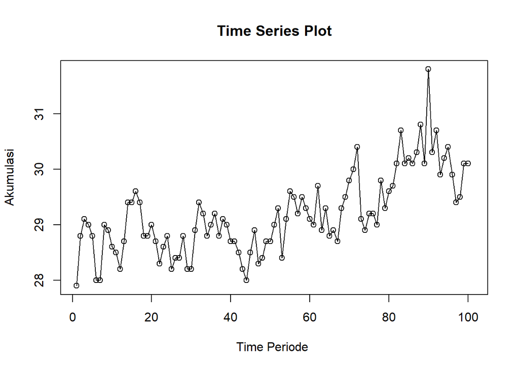

```r
ts.plot(datakeseluruhan.ts, xlab="Time Periode ", ylab="Akumulasi",
        main = "Time Series Plot")
points(datakeseluruhan.ts)
```

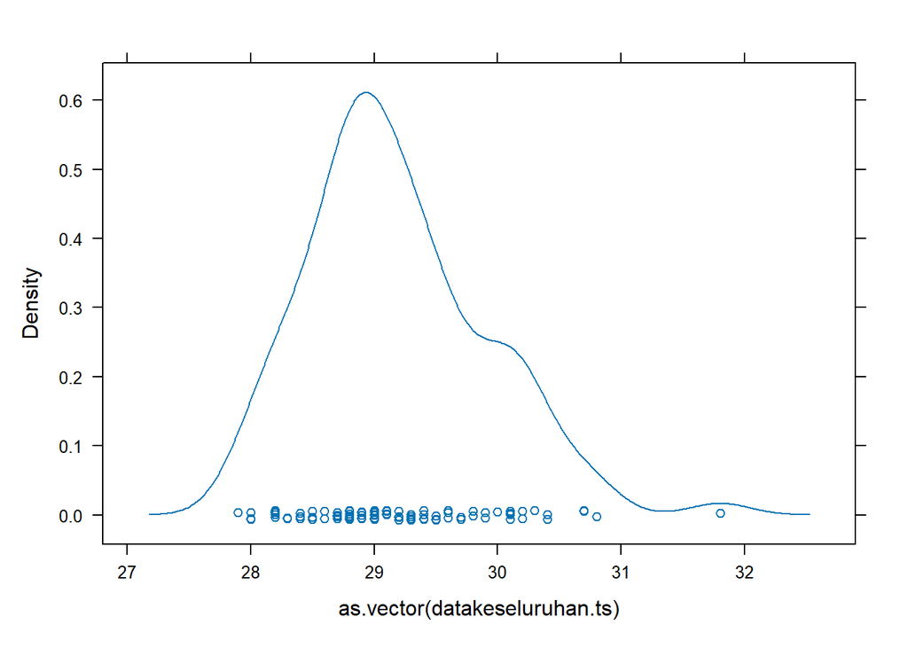

```r
lattice :: densityplot(as.vector (datakeseluruhan.ts))
```

```r
datakeseluruhan.ts <- na.omit(datakeseluruhan.ts)
mean(density(datakeseluruhan.ts)$x)
```

```
## [1] 29.85
```

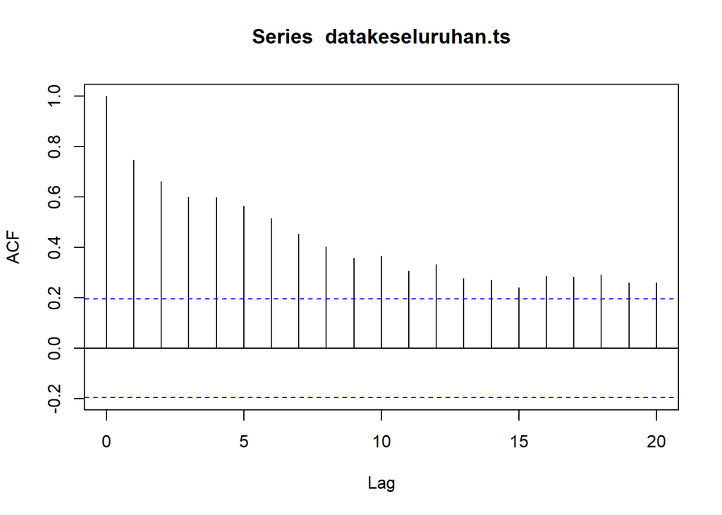

```r
acf(datakeseluruhan.ts)
```

Berdasarkan plot ACF, terlihat bahwa plot ACF pada data tersebut cenderung *slowly* *tails off*

```r
tseries::adf.test(datakeseluruhan.ts)
```

```
##
##  Augmented Dickey-Fuller Test
##
## data:  datakeseluruhan.ts
## Dickey-Fuller = -3.0172, Lag order = 4, p-value = 0.1552
## alternative hypothesis: stationary
```

H0𝐻0 : Data tidak stasioner dalam rataan

H1𝐻1 : Data stasioner dalam rataan

Berdasarkan uji ADF tersebut, didapat *p-value* sebesar 0.1552 yang lebih besar dari taraf nyata 5% sehingga tak tolak H0𝐻0 dan menandakan bahwa data tidak stasioner dalam rataan. Hal ini sesuai dengan hasil eksplorasi menggunakan plot time series dan plot ACF.

```r
library(MASS)
indeks <- seq(1:100)
bc = boxcox(datakeseluruhan.ts~indeks, lambda = seq (-1, 2, by = 0.01))
```

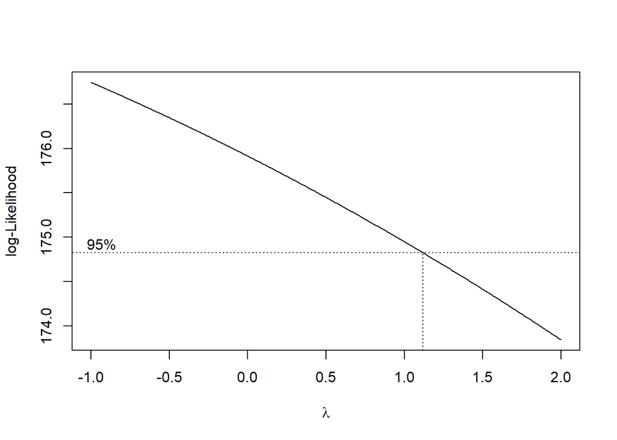

```r
lambda<- bc$x[which.max(bc$y)]
lambda
```

```
## [1] -1
```

```r
bc$x[bc$y > max(bc$y) - 1/2 * qchisq(.95,1)]
```

```
##   [1] -1.00 -0.99 -0.98 -0.97 -0.96 -0.95 -0.94 -0.93 -0.92 -0.91 -0.90 -0.89
##  [13] -0.88 -0.87 -0.86 -0.85 -0.84 -0.83 -0.82 -0.81 -0.80 -0.79 -0.78 -0.77
##  [25] -0.76 -0.75 -0.74 -0.73 -0.72 -0.71 -0.70 -0.69 -0.68 -0.67 -0.66 -0.65
##  [37] -0.64 -0.63 -0.62 -0.61 -0.60 -0.59 -0.58 -0.57 -0.56 -0.55 -0.54 -0.53
##  [49] -0.52 -0.51 -0.50 -0.49 -0.48 -0.47 -0.46 -0.45 -0.44 -0.43 -0.42 -0.41
##  [61] -0.40 -0.39 -0.38 -0.37 -0.36 -0.35 -0.34 -0.33 -0.32 -0.31 -0.30 -0.29
##  [73] -0.28 -0.27 -0.26 -0.25 -0.24 -0.23 -0.22 -0.21 -0.20 -0.19 -0.18 -0.17
##  [85] -0.16 -0.15 -0.14 -0.13 -0.12 -0.11 -0.10 -0.09 -0.08 -0.07 -0.06 -0.05
##  [97] -0.04 -0.03 -0.02 -0.01  0.00  0.01  0.02  0.03  0.04  0.05  0.06  0.07
## [109]  0.08  0.09  0.10  0.11  0.12  0.13  0.14  0.15  0.16  0.17  0.18  0.19
## [121]  0.20  0.21  0.22  0.23  0.24  0.25  0.26  0.27  0.28  0.29  0.30  0.31
## [133]  0.32  0.33  0.34  0.35  0.36  0.37  0.38  0.39  0.40  0.41  0.42  0.43
## [145]  0.44  0.45  0.46  0.47  0.48  0.49  0.50  0.51  0.52  0.53  0.54  0.55
## [157]  0.56  0.57  0.58  0.59  0.60  0.61  0.62  0.63  0.64  0.65  0.66  0.67
## [169]  0.68  0.69  0.70  0.71  0.72  0.73  0.74  0.75  0.76  0.77  0.78  0.79
## [181]  0.80  0.81  0.82  0.83  0.84  0.85  0.86  0.87  0.88  0.89  0.90  0.91
## [193]  0.92  0.93  0.94  0.95  0.96  0.97  0.98  0.99  1.00  1.01  1.02  1.03
## [205]  1.04  1.05  1.06  1.07  1.08  1.09  1.10  1.11
```